# HW 4

```python
## Importing Libraries
%matplotlib inline
import numpy as np
import matplotlib
import matplotlib.pyplot as plt
import scipy
import scipy.signal as signal
from scipy import stats

#this sets the size of the plot to something useful
plt.rcParams["figure.figsize"] = (20,15)
```

### Problem 0: Create fake data

Make gake background data

Make time axis going from $0$ to $100\pi$

```python
t = np.linspace(0,np.pi*100,np.int(1e5))
print(len(t))
```

```
100000
```

Offset sinusoid:

```python
N = 10+np.sin(t)
```

Random background data whose mean and variance depend on N

```python
bkgd = stats.norm.rvs(size=np.int(1e5))*np.sqrt(N)+N
```

### Problem 1: Subsets of data

#### 1a) Make a scatter plot (not a line plot) of the first 1000 data points.

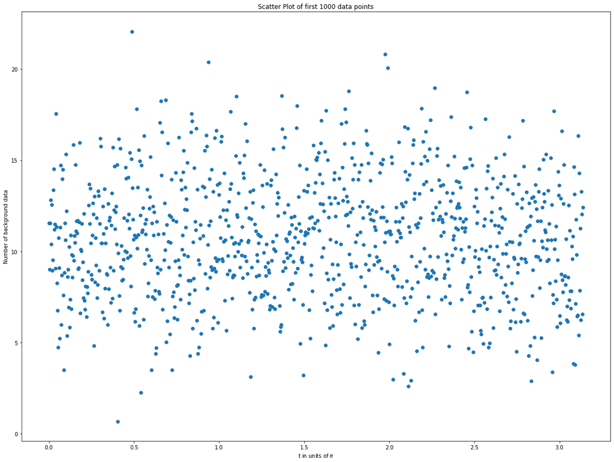

```python
#Take first 10000 data points of the background data
bkgd1000 = bkgd[0:1000]

#Take first 1000 data points of time axis
t1000 = t[0:1000]

#Plot a scatter plot
fig, ax = plt.subplots(1,1)
ax.scatter(t1000, bkgd1000)
#Style plot
ax.set_xlabel('t in units of $\pi$', size = 10)
ax.set_ylabel('Number of background data', size = 10)
ax.set_title('Scatter Plot of first 1000 data points')
plt.show()
```

#### 1b) Generalize your code so you can make a plot of any X contiguous points

To do this I will specify a variable (totalPoints) that is the total number of data points that is to be plotted. This is a subset of data from the background data.

Next I will specify a starting point variable (startPoint) that allows the user to choose where they want their section of data points to start from.

The ending point of the subset of data is dependent on the total number of data points that the user wants to plot.

[figure not shown]

```python
#Specifies total number of data points to be plotted from background data
totalPoints = 2000

#Specifies starting point of dadtapoints
startPoint = 500

#Specifies the ending point
endPoint = totalPoints - startPoint

#Take first 10000 data points of the background data
bkgd1000 = bkgd[startPoint:endPoint]

#Take first 1000 data points of time axis
t1000 = t[startPoint:endPoint]

#Plot a scatter plot
fig, ax = plt.subplots(1,1)
ax.scatter(t1000, bkgd1000)
#Style plot
ax.set_xlabel('t in units of $\pi$', size = 10)
ax.set_ylabel('background data', size = 10)
ax.set_title('Scatter Plot of X contiguous points: 2000 data points starting at point 500')
plt.show()
```

#### 1c) Make a plot of the full data range, but only every 100th point

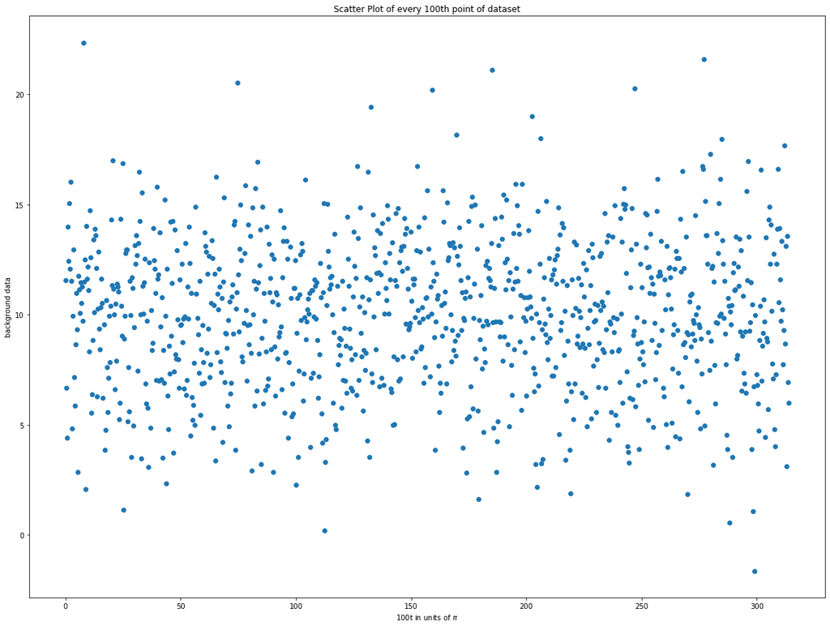

```python
#use numpy sclicing (start:stop:step)
#define the step
step = 100

#Specifies total number of data points to be plotted from background data
totalPoints = len(bkgd)

#Specifies starting point of dadtapoints
startPoint = 0

#Specifies the ending point
endPoint = totalPoints - startPoint

#Take first 10000 data points of the background data
bkgd1000 = bkgd[startPoint:endPoint:step]

#Take first 1000 data points of time axis
t1000 = t[startPoint:endPoint:step]

#Plot a scatter plot
fig, ax = plt.subplots(1,1)
ax.scatter(t1000, bkgd1000)
#Style plot
ax.set_xlabel('100t in units of $\pi$', size = 10)
ax.set_ylabel('background data', size = 10)
ax.set_title('Scatter Plot of every 100th point of dataset')
plt.show()
```

### Problem 2: Density

#### 2a) Make a 2d histogram plot. Play with bin size, use a colorbar.

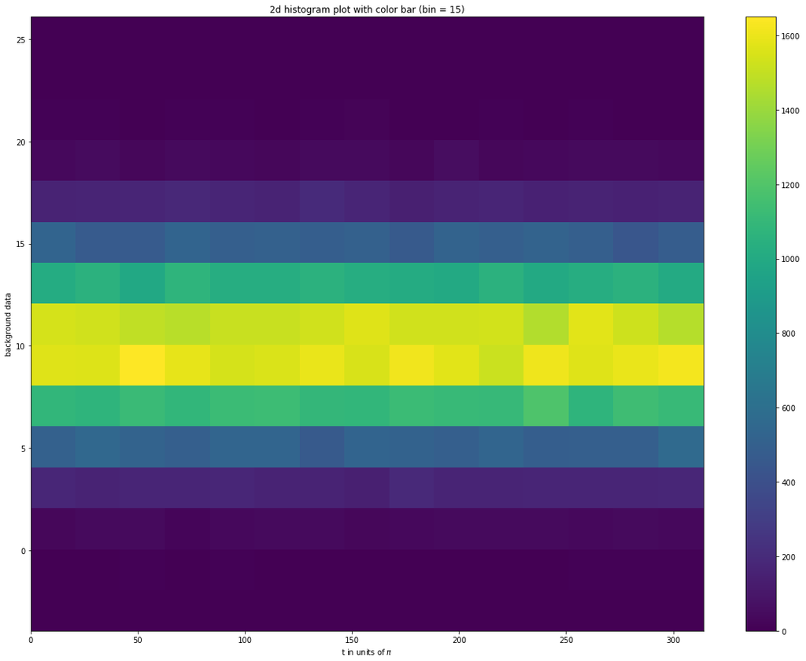

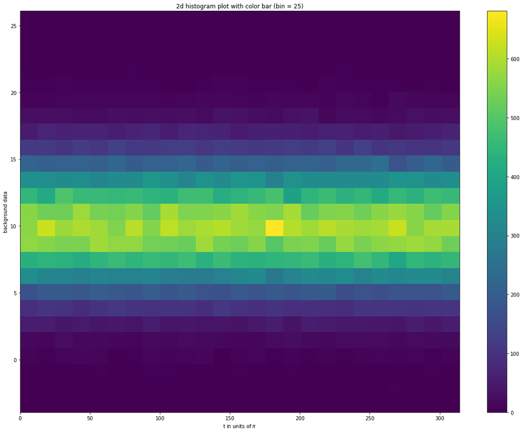

[figure not shown]

```python
#-----density plot 1: Bins = 25-----

#Plot a scatter plot
fig, ax = plt.subplots(1,1)

h = ax.hist2d(t, bkgd, bins = 15)

#Style plot
ax.set_xlabel('t in units of $\pi$', size = 10)
ax.set_ylabel('background data', size = 10)

ax.set_title('2d histogram plot with color bar (bin = 15)')

plt.colorbar(h[3], ax=ax)

plt.show()



#-----density plot 2: Bins = 25-----

#Plot a scatter plot
fig, ax = plt.subplots(1,1)

h = ax.hist2d(t, bkgd, bins = 25)
#Style plot
ax.set_xlabel('t in units of $\pi$', size = 10)
ax.set_ylabel('background data', size = 10)

ax.set_title('2d histogram plot with color bar (bin = 25)')

plt.colorbar(h[3], ax=ax)

plt.show()


#-----density plot 2: Bins = 50-----

#Plot a scatter plot
fig, ax = plt.subplots(1,1)

h = ax.hist2d(t, bkgd, bins = 75)
#Style plot
ax.set_xlabel('t in units of $\pi$', size = 10)
ax.set_ylabel('background data', size = 10)

ax.set_title('2d histogram plot with color bar (bin = 50)')

plt.colorbar(h[3], ax=ax)

plt.show()
```

#### 2b) Clearly explain what is being plotted in your plot (e.g. what does each color mean?)

A 2-d histogram plot groups data points specified by their x and y coordinates into bins. This is useful when analyzing the relationship between two variables in a very large dataset.

The 2-d histogram plot counts the number of observed data points within a specific bin size. The more data points observed within the bin, the higher the intensity.

As we can see in the plots above, as the number of bins increases, the clarity of the data increases increases but to a point. Note using two few or too many bins can cause the data to look smeared and blury. You need to experiment to find the right number for clarity in the data set, where you can see a trend with the yellow line.

### Problem 3: folding

#### 3a) Make an new time variable that folds at a period of 2π. Then make a scatter plot of all your data, but now folded.

Fold the time axis, re-define the data on a folded time axis.

```python
t = np.linspace(0,np.pi*100,np.int(1e5))

tFold = t%np.pi*2
N = 10+np.sin(tFold)
bkgd = stats.norm.rvs(size=np.int(1e5))*np.sqrt(N)+N
```

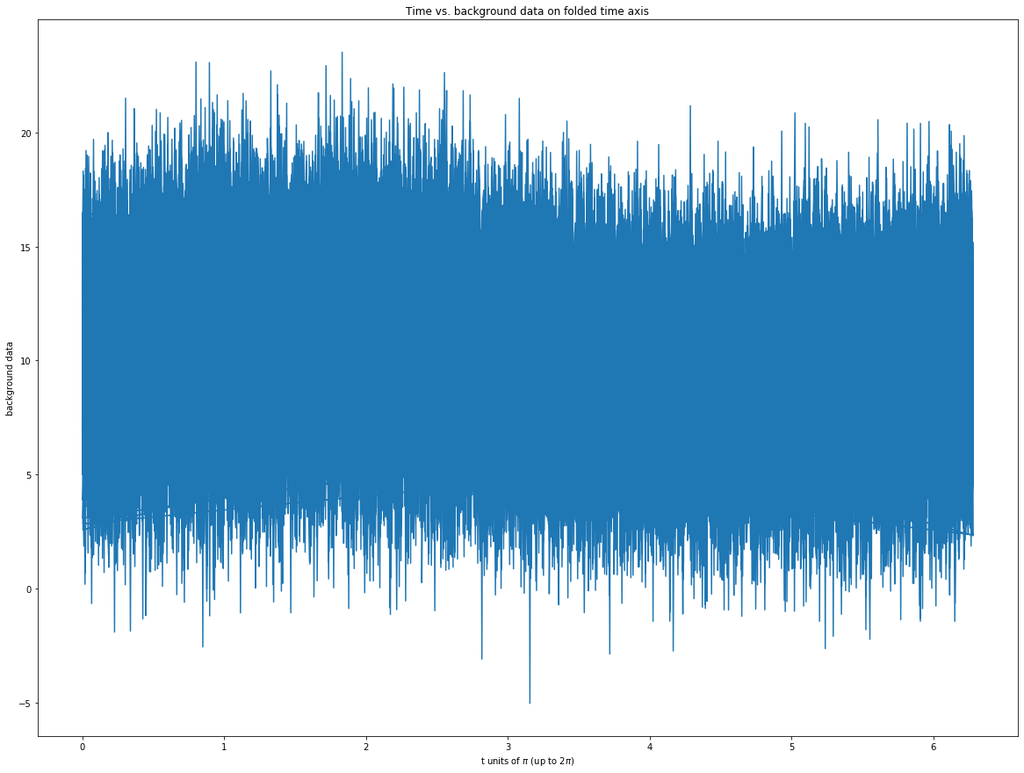

```python
#Plot a scatter plot
fig, ax = plt.subplots(1,1)

ax.plot(tFold, bkgd)
#Style plot
ax.set_xlabel('t units of $\pi$ (up to $2\pi$) ', size = 10)
ax.set_ylabel('background data', size = 10)

ax.set_title('Time vs. background data on folded time axis')

plt.show()
```

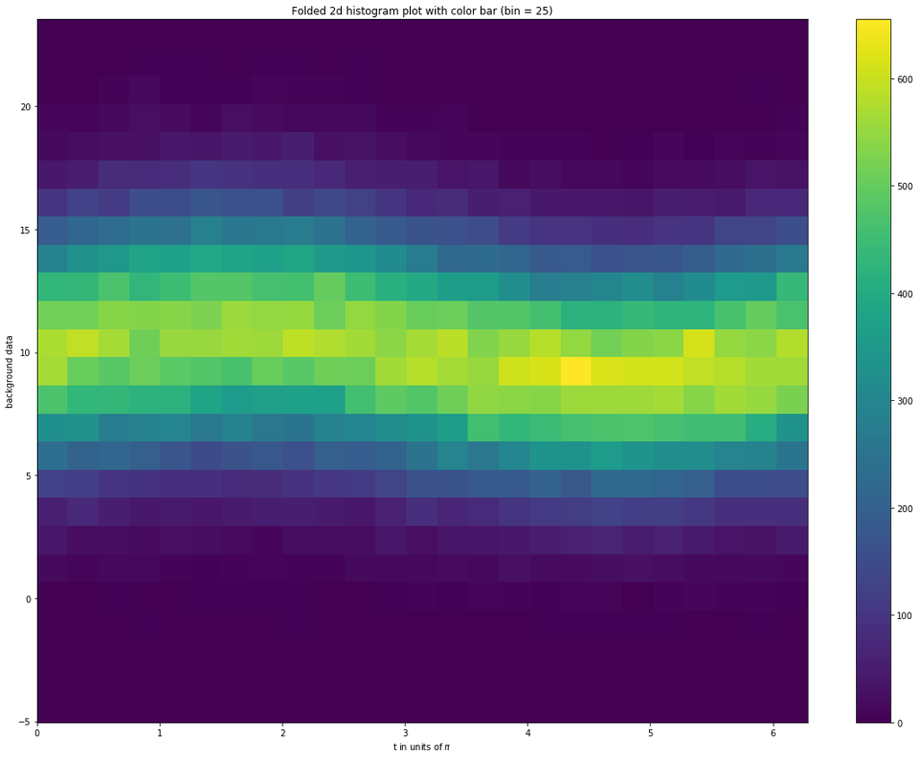

```python
#-----density plot 1: Bins = 25-----

#Plot a scatter plot
fig, ax = plt.subplots(1,1)

h = ax.hist2d(tFold, bkgd, bins = 25)

#Style plot
ax.set_xlabel('t in units of $\pi$', size = 10)
ax.set_ylabel('background data', size = 10)

ax.set_title('Folded 2d histogram plot with color bar (bin = 25)')

plt.colorbar(h[3], ax=ax)

plt.show()
```